# Clustering and PCA Assignment

Name: **Jallepalli Prerna**

Operating System: **Ubuntu**

Date: **24/02/2020**

Time: **23:00:00**

### Other related Instructions

-- All files are extracted from the same folder. There is description of each step written after every code cell.

-- The Questions related to the Assignment are in the cell containing **Questions** as the heading.

**! Important:**

### Importing the libraries

All the necessary libraries are imported, each library has a following commented line stating the using of the library in this assignment

```python
import pandas as pd
# Pandas library helps in extracting the data from csv or excel files
#into the dataframe and then further manipulating the data according to the necessary format

import numpy as np
# Numpy library helps in statistical calculation and also ploting the best fit line for each state in the assignment

import matplotlib.pyplot as plt
# Matplotlib is a visualization library which can be used to plot various charts like, Bar Chart, Pie Chart etc.

import seaborn as sns
# Seaborn is another visualization library which can be used to plot various charts like, Bar Chart, Pie Chart etc.

%matplotlib inline
# The above command is a magical command for ploting graphs in jupyter notebook

# from sklearn.preprocessing import scale

from sklearn.cluster import KMeans
# For implementing the KMeans model to the data

from sklearn.preprocessing import StandardScaler
# Standard Scalar is for scaling of the dataset

# Necesary libraries for Hirarchical clustering -Single Linkage and Complete Linkage
from scipy.cluster.hierarchy import linkage
from scipy.cluster.hierarchy import dendrogram
from scipy.cluster.hierarchy import cut_tree
```

### Data Extraction

Extracting the data from the csv file

```python
dataset = pd.read_csv("Country-data.csv")
# Extract the data

dataset.head()
# Printing out the top 5 records of the dataset
```

|  | country | child_mort | exports | health | imports | income | inflation | life_expec | total_fer | gdpp |
| --- | --- | --- | --- | --- | --- | --- | --- | --- | --- | --- |
| 0 | Afghanistan | 90.2 | 10.0 | 7.58 | 44.9 | 1610 | 9.44 | 56.2 | 5.82 | 553 |
| 1 | Albania | 16.6 | 28.0 | 6.55 | 48.6 | 9930 | 4.49 | 76.3 | 1.65 | 4090 |
| 2 | Algeria | 27.3 | 38.4 | 4.17 | 31.4 | 12900 | 16.10 | 76.5 | 2.89 | 4460 |
| 3 | Angola | 119.0 | 62.3 | 2.85 | 42.9 | 5900 | 22.40 | 60.1 | 6.16 | 3530 |
| 4 | Antigua and Barbuda | 10.3 | 45.5 | 6.03 | 58.9 | 19100 | 1.44 | 76.8 | 2.13 | 12200 |

```python
dataset["imports"] = (dataset["gdpp"] * dataset["imports"])/100
dataset["exports"] = (dataset["gdpp"] * dataset["exports"])/100
dataset["health"] = (dataset["gdpp"] * dataset["health"])/100
```

```python
dataset.shape
```

```
(167, 10)
```

```python
dataset.info()
```

```
<class 'pandas.core.frame.DataFrame'>
RangeIndex: 167 entries, 0 to 166
Data columns (total 10 columns):
country       167 non-null object
child_mort    167 non-null float64
exports       167 non-null float64
health        167 non-null float64
imports       167 non-null float64
income        167 non-null int64
inflation     167 non-null float64
life_expec    167 non-null float64
total_fer     167 non-null float64
gdpp          167 non-null int64
dtypes: float64(7), int64(2), object(1)
memory usage: 13.2+ KB
```

Overview

Dataset info

| Number of variables | 10 |
| --- | --- |
| Number of observations | 167 |
| Total Missing (%) | 0.0% |
| Total size in memory | 13.2 KiB |
| Average record size in memory | 80.8 B |

Variables types

| Numeric | 7 |
| --- | --- |
| Categorical | 0 |
| Boolean | 0 |
| Date | 0 |
| Text (Unique) | 1 |
| Rejected | 2 |
| Unsupported | 0 |

Warnings

- `imports` is highly correlated with `exports` (ρ = 0.98769) Rejected

- `gdpp` is highly correlated with `health` (ρ = 0.91659) Rejected

Variables

country  
Categorical, Unique

| First 3 values |
| --- |
| Namibia |
| Seychelles |
| Kenya |

| Last 3 values |
| --- |
| United States |
| Gambia |
| Guinea |

Toggle details

First 10 values

| Value | Count | Frequency (%) |  |
| --- | --- | --- | --- |
| Afghanistan | 1 | 0.6% |  |
| Albania | 1 | 0.6% |  |
| Algeria | 1 | 0.6% |  |
| Angola | 1 | 0.6% |  |
| Antigua and Barbuda | 1 | 0.6% |  |

Last 10 values

| Value | Count | Frequency (%) |  |
| --- | --- | --- | --- |
| Vanuatu | 1 | 0.6% |  |
| Venezuela | 1 | 0.6% |  |
| Vietnam | 1 | 0.6% |  |
| Yemen | 1 | 0.6% |  |
| Zambia | 1 | 0.6% |  |

child_mort  
Numeric

| Distinct count | 139 |
| --- | --- |
| Unique (%) | 83.2% |
| Missing (%) | 0.0% |
| Missing (n) | 0 |
| Infinite (%) | 0.0% |
| Infinite (n) | 0 |

| Mean | 38.27 |
| --- | --- |
| Minimum | 2.6 |
| Maximum | 208 |
| Zeros (%) | 0.0% |

Toggle details

**Statistics**

Quantile statistics

| Minimum | 2.6 |
| --- | --- |
| 5-th percentile | 3.46 |
| Q1 | 8.25 |
| Median | 19.3 |
| Q3 | 62.1 |
| 95-th percentile | 116 |
| Maximum | 208 |
| Range | 205.4 |
| Interquartile range | 53.85 |

Descriptive statistics

| Standard deviation | 40.329 |
| --- | --- |
| Coef of variation | 1.0538 |
| Kurtosis | 1.7669 |
| Mean | 38.27 |
| MAD | 32.309 |
| Skewness | 1.4508 |
| Sum | 6391.1 |
| Variance | 1626.4 |
| Memory size | 1.4 KiB |

**Histogram**

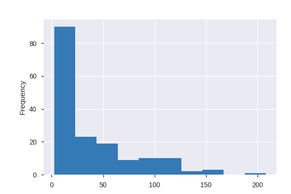

**Common Values**

| Value | Count | Frequency (%) |  |
| --- | --- | --- | --- |
| 4.5 | 4 | 2.4% |  |
| 3.2 | 3 | 1.8% |  |
| 111.0 | 3 | 1.8% |  |
| 4.2 | 3 | 1.8% |  |
| 24.1 | 3 | 1.8% |  |
| 62.2 | 2 | 1.2% |  |
| 17.4 | 2 | 1.2% |  |
| 18.1 | 2 | 1.2% |  |
| 11.7 | 2 | 1.2% |  |
| 2.8 | 2 | 1.2% |  |
| Other values (129) | 141 | 84.4% |  |

**Extreme Values**

Minimum 5 values

| Value | Count | Frequency (%) |  |
| --- | --- | --- | --- |
| 2.6 | 1 | 0.6% |  |
| 2.8 | 2 | 1.2% |  |
| 3.0 | 2 | 1.2% |  |
| 3.2 | 3 | 1.8% |  |
| 3.4 | 1 | 0.6% |  |

Maximum 5 values

| Value | Count | Frequency (%) |  |
| --- | --- | --- | --- |
| 137.0 | 1 | 0.6% |  |
| 149.0 | 1 | 0.6% |  |
| 150.0 | 1 | 0.6% |  |
| 160.0 | 1 | 0.6% |  |
| 208.0 | 1 | 0.6% |  |

exports  
Numeric

| Distinct count | 167 |
| --- | --- |
| Unique (%) | 100.0% |
| Missing (%) | 0.0% |
| Missing (n) | 0 |
| Infinite (%) | 0.0% |
| Infinite (n) | 0 |

| Mean | 7420.6 |
| --- | --- |
| Minimum | 1.0769 |
| Maximum | 183750 |
| Zeros (%) | 0.0% |

Toggle details

**Statistics**

Quantile statistics

| Minimum | 1.0769 |
| --- | --- |
| 5-th percentile | 70.469 |
| Q1 | 447.14 |
| Median | 1777.4 |
| Q3 | 7278 |
| 95-th percentile | 31385 |
| Maximum | 183750 |
| Range | 183750 |
| Interquartile range | 6830.9 |

Descriptive statistics

| Standard deviation | 17974 |
| --- | --- |
| Coef of variation | 2.4222 |
| Kurtosis | 58.688 |
| Mean | 7420.6 |
| MAD | 8667.2 |
| Skewness | 6.7202 |
| Sum | 1239200 |
| Variance | 323060000 |
| Memory size | 1.4 KiB |

**Histogram**

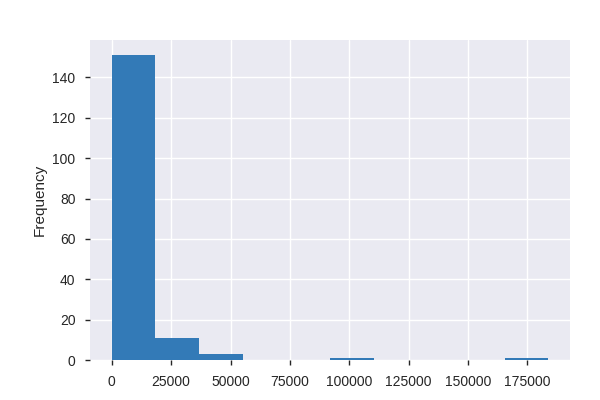

**Common Values**

| Value | Count | Frequency (%) |  |
| --- | --- | --- | --- |
| 1199.28 | 1 | 0.6% |  |
| 110.4 | 1 | 0.6% |  |
| 7937.5999999999985 | 1 | 0.6% |  |
| 403.56 | 1 | 0.6% |  |
| 10715.8 | 1 | 0.6% |  |
| 755.73 | 1 | 0.6% |  |
| 437.46 | 1 | 0.6% |  |
| 454.08 | 1 | 0.6% |  |
| 12680.1 | 1 | 0.6% |  |
| 2199.19 | 1 | 0.6% |  |
| Other values (157) | 157 | 94.0% |  |

**Extreme Values**

Minimum 5 values

| Value | Count | Frequency (%) |  |
| --- | --- | --- | --- |
| 1.0769199999999999 | 1 | 0.6% |  |
| 20.6052 | 1 | 0.6% |  |
| 23.0878 | 1 | 0.6% |  |
| 52.628 | 1 | 0.6% |  |
| 55.3 | 1 | 0.6% |  |

Maximum 5 values

| Value | Count | Frequency (%) |  |
| --- | --- | --- | --- |
| 43796.9 | 1 | 0.6% |  |
| 47744.0 | 1 | 0.6% |  |
| 50161.0 | 1 | 0.6% |  |
| 93200.0 | 1 | 0.6% |  |
| 183750.0 | 1 | 0.6% |  |

health  
Numeric

| Distinct count | 167 |
| --- | --- |
| Unique (%) | 100.0% |
| Missing (%) | 0.0% |
| Missing (n) | 0 |
| Infinite (%) | 0.0% |
| Infinite (n) | 0 |

| Mean | 1056.7 |
| --- | --- |
| Minimum | 12.821 |
| Maximum | 8663.6 |
| Zeros (%) | 0.0% |

Toggle details

**Statistics**

Quantile statistics

| Minimum | 12.821 |
| --- | --- |
| 5-th percentile | 26.716 |
| Q1 | 78.535 |
| Median | 321.89 |
| Q3 | 976.94 |
| 95-th percentile | 4966.7 |
| Maximum | 8663.6 |
| Range | 8650.8 |
| Interquartile range | 898.4 |

Descriptive statistics

| Standard deviation | 1801.4 |
| --- | --- |
| Coef of variation | 1.7047 |
| Kurtosis | 6.23 |
| Mean | 1056.7 |
| MAD | 1197.3 |
| Skewness | 2.526 |
| Sum | 176470 |
| Variance | 3245100 |
| Memory size | 1.4 KiB |

**Histogram**

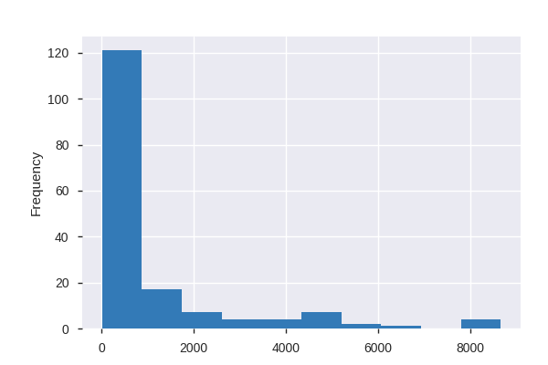

**Common Values**

| Value | Count | Frequency (%) |  |
| --- | --- | --- | --- |
| 8663.599999999999 | 1 | 0.6% |  |
| 1047.6 | 1 | 0.6% |  |
| 229.284 | 1 | 0.6% |  |
| 54.675 | 1 | 0.6% |  |
| 155.925 | 1 | 0.6% |  |
| 834.3 | 1 | 0.6% |  |
| 527.0500000000001 | 1 | 0.6% |  |
| 1009.12 | 1 | 0.6% |  |
| 113.36 | 1 | 0.6% |  |
| 26.796 | 1 | 0.6% |  |
| Other values (157) | 157 | 94.0% |  |

**Extreme Values**

Minimum 5 values

| Value | Count | Frequency (%) |  |
| --- | --- | --- | --- |
| 12.821200000000001 | 1 | 0.6% |  |
| 15.5701 | 1 | 0.6% |  |
| 17.750799999999998 | 1 | 0.6% |  |
| 17.9568 | 1 | 0.6% |  |
| 19.4636 | 1 | 0.6% |  |

Maximum 5 values

| Value | Count | Frequency (%) |  |
| --- | --- | --- | --- |
| 6612.0 | 1 | 0.6% |  |
| 8158.5 | 1 | 0.6% |  |
| 8323.44 | 1 | 0.6% |  |
| 8579.0 | 1 | 0.6% |  |
| 8663.599999999999 | 1 | 0.6% |  |

imports  
Highly correlated

*This variable is highly correlated with `exports` and should be ignored for analysis*

| Correlation | 0.98769 |
| --- | --- |

income  
Numeric

| Distinct count | 156 |
| --- | --- |
| Unique (%) | 93.4% |
| Missing (%) | 0.0% |
| Missing (n) | 0 |
| Infinite (%) | 0.0% |
| Infinite (n) | 0 |

| Mean | 17145 |
| --- | --- |
| Minimum | 609 |
| Maximum | 125000 |
| Zeros (%) | 0.0% |

Toggle details

**Statistics**

Quantile statistics

| Minimum | 609 |
| --- | --- |
| 5-th percentile | 1213 |
| Q1 | 3355 |
| Median | 9960 |
| Q3 | 22800 |
| 95-th percentile | 48290 |
| Maximum | 125000 |
| Range | 124391 |
| Interquartile range | 19445 |

Descriptive statistics

| Standard deviation | 19278 |
| --- | --- |
| Coef of variation | 1.1244 |
| Kurtosis | 7.0287 |
| Mean | 17145 |
| MAD | 13955 |
| Skewness | 2.2315 |
| Sum | 2863163 |
| Variance | 371640000 |
| Memory size | 1.4 KiB |

**Histogram**

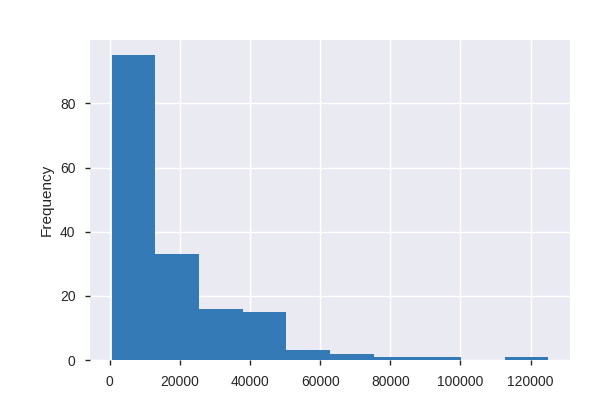

**Common Values**

| Value | Count | Frequency (%) |  |
| --- | --- | --- | --- |
| 28700 | 2 | 1.2% |  |
| 41100 | 2 | 1.2% |  |
| 28300 | 2 | 1.2% |  |
| 15300 | 2 | 1.2% |  |
| 29600 | 2 | 1.2% |  |
| 15400 | 2 | 1.2% |  |
| 36200 | 2 | 1.2% |  |
| 1390 | 2 | 1.2% |  |
| 12700 | 2 | 1.2% |  |
| 21100 | 2 | 1.2% |  |
| Other values (146) | 147 | 88.0% |  |

**Extreme Values**

Minimum 5 values

| Value | Count | Frequency (%) |  |
| --- | --- | --- | --- |
| 609 | 1 | 0.6% |  |
| 700 | 1 | 0.6% |  |
| 764 | 1 | 0.6% |  |
| 814 | 1 | 0.6% |  |
| 888 | 1 | 0.6% |  |

Maximum 5 values

| Value | Count | Frequency (%) |  |
| --- | --- | --- | --- |
| 72100 | 1 | 0.6% |  |
| 75200 | 1 | 0.6% |  |
| 80600 | 1 | 0.6% |  |
| 91700 | 1 | 0.6% |  |
| 125000 | 1 | 0.6% |  |

inflation  
Numeric

| Distinct count | 156 |
| --- | --- |
| Unique (%) | 93.4% |
| Missing (%) | 0.0% |
| Missing (n) | 0 |
| Infinite (%) | 0.0% |
| Infinite (n) | 0 |

| Mean | 7.7818 |
| --- | --- |
| Minimum | -4.21 |
| Maximum | 104 |
| Zeros (%) | 0.0% |

Toggle details

**Statistics**

Quantile statistics

| Minimum | -4.21 |
| --- | --- |
| 5-th percentile | 0.1834 |
| Q1 | 1.81 |
| Median | 5.39 |
| Q3 | 10.75 |
| 95-th percentile | 20.87 |
| Maximum | 104 |
| Range | 108.21 |
| Interquartile range | 8.94 |

Descriptive statistics

| Standard deviation | 10.571 |
| --- | --- |
| Coef of variation | 1.3584 |
| Kurtosis | 41.743 |
| Mean | 7.7818 |
| MAD | 6.3096 |
| Skewness | 5.154 |
| Sum | 1299.6 |
| Variance | 111.74 |
| Memory size | 1.4 KiB |

**Histogram**

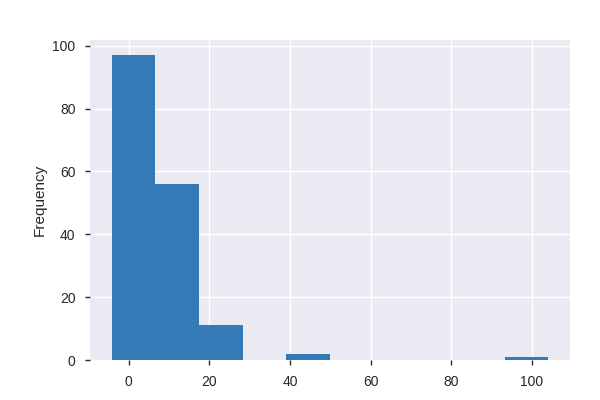

**Common Values**

| Value | Count | Frequency (%) |  |
| --- | --- | --- | --- |
| 16.6 | 3 | 1.8% |  |
| 14.2 | 2 | 1.2% |  |
| 12.1 | 2 | 1.2% |  |
| 16.1 | 2 | 1.2% |  |
| 5.47 | 2 | 1.2% |  |
| 15.1 | 2 | 1.2% |  |
| 6.81 | 2 | 1.2% |  |
| 12.5 | 2 | 1.2% |  |
| 2.01 | 2 | 1.2% |  |
| 17.2 | 2 | 1.2% |  |
| Other values (146) | 146 | 87.4% |  |

**Extreme Values**

Minimum 5 values

| Value | Count | Frequency (%) |  |
| --- | --- | --- | --- |
| -4.21 | 1 | 0.6% |  |
| -3.22 | 1 | 0.6% |  |
| -1.9 | 1 | 0.6% |  |
| -1.43 | 1 | 0.6% |  |
| -0.987 | 1 | 0.6% |  |

Maximum 5 values

| Value | Count | Frequency (%) |  |
| --- | --- | --- | --- |
| 24.9 | 1 | 0.6% |  |
| 26.5 | 1 | 0.6% |  |
| 39.2 | 1 | 0.6% |  |
| 45.9 | 1 | 0.6% |  |
| 104.0 | 1 | 0.6% |  |

life_expec  
Numeric

| Distinct count | 127 |
| --- | --- |
| Unique (%) | 76.0% |
| Missing (%) | 0.0% |
| Missing (n) | 0 |
| Infinite (%) | 0.0% |
| Infinite (n) | 0 |

| Mean | 70.556 |
| --- | --- |
| Minimum | 32.1 |
| Maximum | 82.8 |
| Zeros (%) | 0.0% |

Toggle details

**Statistics**

Quantile statistics

| Minimum | 32.1 |
| --- | --- |
| 5-th percentile | 55.78 |
| Q1 | 65.3 |
| Median | 73.1 |
| Q3 | 76.8 |
| 95-th percentile | 81.4 |
| Maximum | 82.8 |
| Range | 50.7 |
| Interquartile range | 11.5 |

Descriptive statistics

| Standard deviation | 8.8932 |
| --- | --- |
| Coef of variation | 0.12604 |
| Kurtosis | 1.1516 |
| Mean | 70.556 |
| MAD | 7.2193 |
| Skewness | -0.971 |
| Sum | 11783 |
| Variance | 79.089 |
| Memory size | 1.4 KiB |

**Histogram**

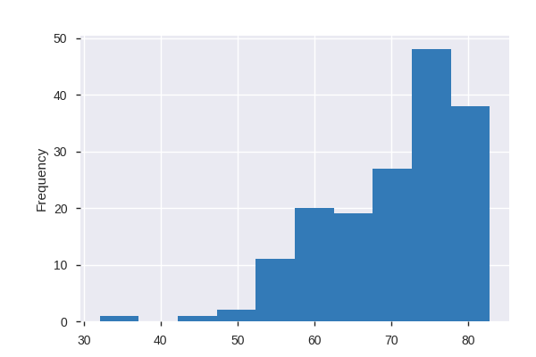

**Common Values**

| Value | Count | Frequency (%) |  |
| --- | --- | --- | --- |
| 74.5 | 3 | 1.8% |  |
| 79.5 | 3 | 1.8% |  |
| 70.4 | 3 | 1.8% |  |
| 80.4 | 3 | 1.8% |  |
| 76.4 | 3 | 1.8% |  |
| 76.3 | 3 | 1.8% |  |
| 69.9 | 2 | 1.2% |  |
| 81.3 | 2 | 1.2% |  |
| 74.1 | 2 | 1.2% |  |
| 76.7 | 2 | 1.2% |  |
| Other values (117) | 141 | 84.4% |  |

**Extreme Values**

Minimum 5 values

| Value | Count | Frequency (%) |  |
| --- | --- | --- | --- |
| 32.1 | 1 | 0.6% |  |
| 46.5 | 1 | 0.6% |  |
| 47.5 | 1 | 0.6% |  |
| 52.0 | 1 | 0.6% |  |
| 53.1 | 1 | 0.6% |  |

Maximum 5 values

| Value | Count | Frequency (%) |  |
| --- | --- | --- | --- |
| 81.9 | 1 | 0.6% |  |
| 82.0 | 2 | 1.2% |  |
| 82.2 | 1 | 0.6% |  |
| 82.7 | 1 | 0.6% |  |
| 82.8 | 1 | 0.6% |  |

total_fer  
Numeric

| Distinct count | 138 |
| --- | --- |
| Unique (%) | 82.6% |
| Missing (%) | 0.0% |
| Missing (n) | 0 |
| Infinite (%) | 0.0% |
| Infinite (n) | 0 |

| Mean | 2.948 |
| --- | --- |
| Minimum | 1.15 |
| Maximum | 7.49 |
| Zeros (%) | 0.0% |

Toggle details

**Statistics**

Quantile statistics

| Minimum | 1.15 |
| --- | --- |
| 5-th percentile | 1.39 |
| Q1 | 1.795 |
| Median | 2.41 |
| Q3 | 3.88 |
| 95-th percentile | 5.861 |
| Maximum | 7.49 |
| Range | 6.34 |
| Interquartile range | 2.085 |

Descriptive statistics

| Standard deviation | 1.5138 |
| --- | --- |
| Coef of variation | 0.51352 |
| Kurtosis | -0.18678 |
| Mean | 2.948 |
| MAD | 1.2529 |
| Skewness | 0.96709 |
| Sum | 492.31 |
| Variance | 2.2917 |
| Memory size | 1.4 KiB |

**Histogram**

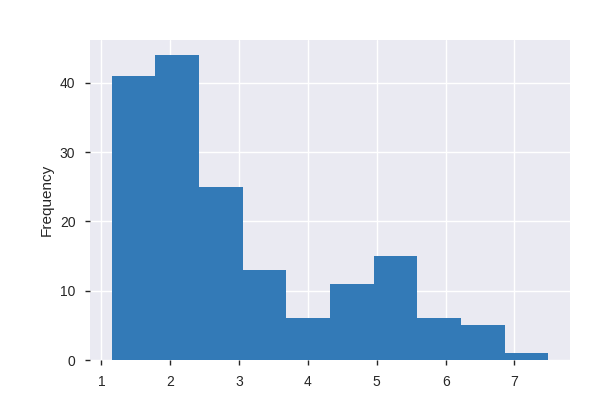

**Common Values**

| Value | Count | Frequency (%) |  |
| --- | --- | --- | --- |
| 1.92 | 4 | 2.4% |  |
| 1.57 | 4 | 2.4% |  |
| 1.87 | 3 | 1.8% |  |
| 2.17 | 3 | 1.8% |  |
| 1.39 | 3 | 1.8% |  |
| 2.6 | 3 | 1.8% |  |
| 1.86 | 2 | 1.2% |  |
| 2.41 | 2 | 1.2% |  |
| 2.67 | 2 | 1.2% |  |
| 1.93 | 2 | 1.2% |  |
| Other values (128) | 139 | 83.2% |  |

**Extreme Values**

Minimum 5 values

| Value | Count | Frequency (%) |  |
| --- | --- | --- | --- |
| 1.15 | 1 | 0.6% |  |
| 1.23 | 1 | 0.6% |  |
| 1.25 | 1 | 0.6% |  |
| 1.27 | 1 | 0.6% |  |
| 1.31 | 1 | 0.6% |  |

Maximum 5 values

| Value | Count | Frequency (%) |  |
| --- | --- | --- | --- |
| 6.26 | 1 | 0.6% |  |
| 6.54 | 1 | 0.6% |  |
| 6.55 | 1 | 0.6% |  |
| 6.59 | 1 | 0.6% |  |
| 7.49 | 1 | 0.6% |  |

gdpp  
Highly correlated

*This variable is highly correlated with `health` and should be ignored for analysis*

| Correlation | 0.91659 |
| --- | --- |

Correlations

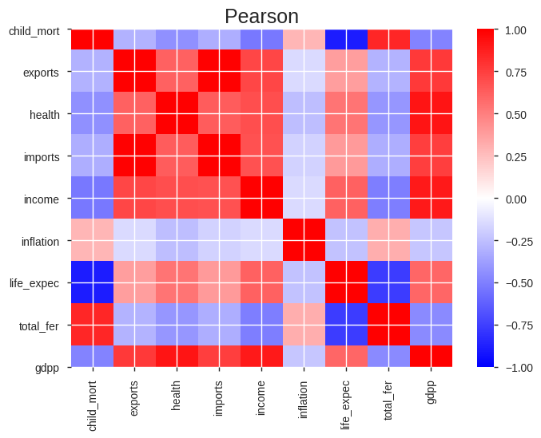

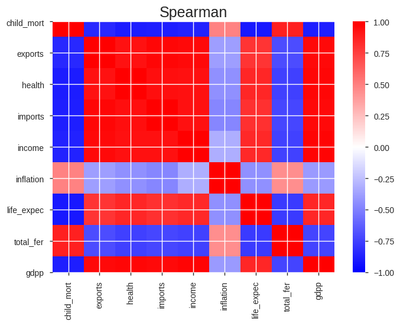

Sample

|  | country | child_mort | exports | health | imports | income | inflation | life_expec | total_fer | gdpp |
| --- | --- | --- | --- | --- | --- | --- | --- | --- | --- | --- |
| 0 | Afghanistan | 90.2 | 55.30 | 41.9174 | 248.297 | 1610 | 9.44 | 56.2 | 5.82 | 553 |
| 1 | Albania | 16.6 | 1145.20 | 267.8950 | 1987.740 | 9930 | 4.49 | 76.3 | 1.65 | 4090 |
| 2 | Algeria | 27.3 | 1712.64 | 185.9820 | 1400.440 | 12900 | 16.10 | 76.5 | 2.89 | 4460 |
| 3 | Angola | 119.0 | 2199.19 | 100.6050 | 1514.370 | 5900 | 22.40 | 60.1 | 6.16 | 3530 |
| 4 | Antigua and Barbuda | 10.3 | 5551.00 | 735.6600 | 7185.800 | 19100 | 1.44 | 76.8 | 2.13 | 12200 |

```python
import pandas_profiling
# Importing the pandas profiling for performing the basic EDA of the data

report = pandas_profiling.ProfileReport(dataset)
# Store the report into the variable report

report
```

### Summary of EDA

- No columns have any missing values
- All the variables except for "country" column are numerical
- "country" column acts as a Unique column.

## Outliers

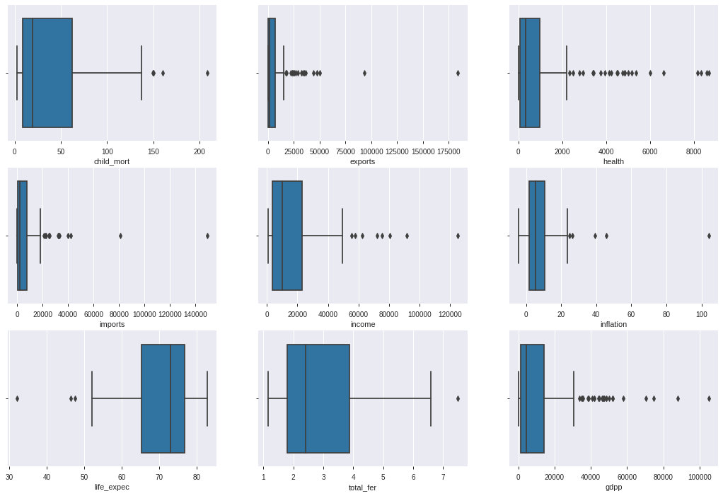

```python
%matplotlib inline
var = list(dataset.columns)
# extract the column names

var.remove('country')
# popping out the country column as it is not necessary for the outlier analysis

plt.figure(figsize=(18,12))
for i in enumerate(var):
    plt.subplot(3, 3, i[0]+1)
    sns.boxplot(x=i[1], data=dataset)
    # Boxplot is plotted for every column so that outliers could be detected
plt.show()
# plt.savefig("outliers.png")
```

```python
# Whenever you have many outliers: Keep them for clustering as Clustering may create seperate cluetsres for all these outliers.
# Less Outlier: Devieate the cluster center For treating them you can cap them or drop them
# Capping: less outliers
# Remove: Good number of data points

q1 = dataset["gdpp"].quantile(0.00)
q2 = dataset["gdpp"].quantile(0.80)
dataset = dataset[(dataset["gdpp"]>=q1) & (dataset["gdpp"]<=q2)]


q1 = dataset["life_expec"].quantile(0.01)
q2 = dataset["life_expec"].quantile(1)
dataset = dataset[(dataset["life_expec"]>=q1) & (dataset["life_expec"]<=q2)]


q1 = dataset["inflation"].quantile(0.00)
q2 = dataset["inflation"].quantile(0.975)
dataset = dataset[(dataset["inflation"]>=q1) & (dataset["inflation"]<=q2)]


q1 = dataset["health"].quantile(0.00)
q2 = dataset["health"].quantile(0.995)
dataset = dataset[(dataset["health"]>=q1) & (dataset["health"]<=q2)]

q1 = dataset["imports"].quantile(0.00)
q2 = dataset["imports"].quantile(0.995)
dataset = dataset[(dataset["imports"]>=q1) & (dataset["imports"]<=q2)]


q1 = dataset["child_mort"].quantile(0.00)
q2 = dataset["child_mort"].quantile(0.995)
dataset = dataset[(dataset["child_mort"]>=q1) & (dataset["child_mort"]<=q2)]

q1 = dataset["income"].quantile(0.00)
q2 = dataset["income"].quantile(0.995)
dataset = dataset[(dataset["income"]>=q1) & (dataset["income"]<=q2)]

# Removing all the records which were outliers for each variable

dataset.shape
```

```
(123, 10)
```

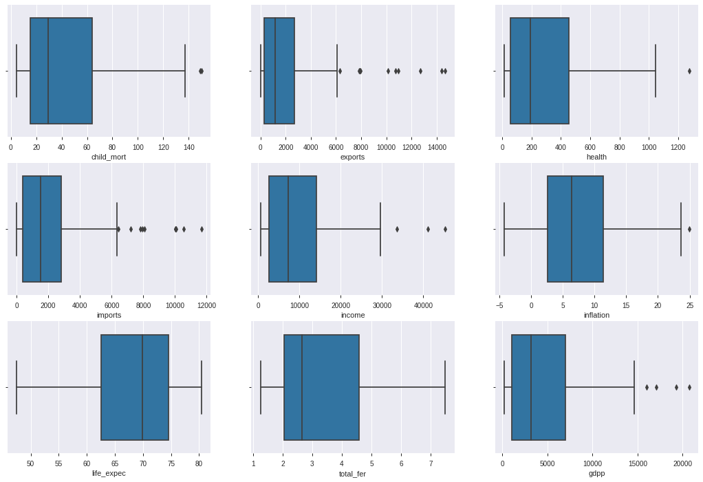

```python
# Replotting the boxplot for each variable
plt.figure(figsize=(18,12))
for i in enumerate(var):
    plt.subplot(3, 3, i[0]+1)
    sns.boxplot(x=i[1], data=dataset)
plt.show()
# plt.savefig("afteroutliers.png")
```

```python
# Extracting the ID column so that it can be used afte performing PCA
countries = dataset["country"]

dataset1 = dataset.drop("country", axis=1)

dataset1.shape
```

```
(123, 9)
```

```python
scaler = StandardScaler()
# Standardize the dataset

dataset2 = scaler.fit_transform(dataset1)

dataset2.max()
# Finding out the maximum value of the entire dataset
```

```
4.358739754798125
```

### Question 4, 5 & 6

Performing PCA on the data we have. Using svd_solver as randomized and random_state=42

Answering the below questions:

- Which variable explains the maximum variance in the original dataset
- What is the first component of the first vector obtained from pca_components
- What is the variance explained by the principa components

```python
# Check the current variance of each column
100*dataset1.var()/(sum(dataset1.var()))
```

```
child_mort     0.001324
exports        8.351382
health         0.086436
imports        6.082314
income        65.841484
inflation      0.000037
life_expec     0.000053
total_fer      0.000002
gdpp          19.636969
dtype: float64
```

```python
# Importing the PCA module
from sklearn.decomposition import PCA

pca = PCA(svd_solver="randomized", random_state=42)
# IMplementing PCA to the dataset

pca.fit(dataset2)
```

```
PCA(copy=True, iterated_power='auto', n_components=None, random_state=42,
    svd_solver='randomized', tol=0.0, whiten=False)
```

```python
pca.components_
```

```
array([[-0.32405562,  0.34780734,  0.36610989,  0.3666591 ,  0.37990721,
        -0.07955745,  0.31767283, -0.3173626 ,  0.39146996],
       [ 0.43897377,  0.39298436,  0.08306276,  0.2464548 ,  0.24053405,
         0.32466577, -0.40955863,  0.44710097,  0.23307487],
       [-0.18675794, -0.08205877, -0.08805654, -0.22912622,  0.13366873,
         0.905592  ,  0.19601605, -0.14720991, -0.00881997],
       [ 0.12235065, -0.40347328,  0.78205189, -0.35337683, -0.0518607 ,
         0.02032059, -0.12132619,  0.05297809,  0.25520601],
       [-0.19729373,  0.0205626 , -0.00946259,  0.04847566, -0.00795515,
         0.04876784, -0.78511848, -0.5815049 , -0.03481925],
       [ 0.29848659, -0.04327412, -0.30113674, -0.51169491,  0.65253053,
        -0.22958802,  0.01085496, -0.19533049,  0.19934772],
       [-0.71890526, -0.07732021, -0.09967203, -0.17148469,  0.23918414,
        -0.10056155, -0.24739068,  0.54383604,  0.11650677],
       [-0.0867837 ,  0.7317718 ,  0.1235189 , -0.57777362, -0.32261533,
        -0.04649172,  0.02126167, -0.02141001, -0.02732712],
       [ 0.00815642, -0.10632575, -0.35176796, -0.00601679, -0.4360137 ,
         0.01974544,  0.00450523, -0.04884978,  0.81972372]])
```

**First component of the first vector obtained from pca_components**

```python
pca.explained_variance_ratio_
```

```
array([0.63908538, 0.16673894, 0.10799364, 0.03570876, 0.0216186 ,
       0.01415851, 0.01053613, 0.002603  , 0.00155703])
```

**What is the variance explained by the first principle component**

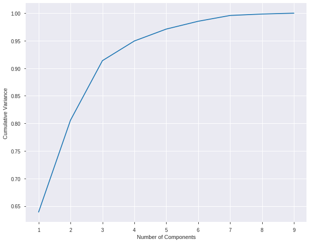

```python
# Ploting the Scree Plot
fig = plt.figure(figsize=(10,8))
plt.plot([1,2,3,4,5,6,7,8,9], np.cumsum(pca.explained_variance_ratio_))
plt.xlabel("Number of Components")
plt.ylabel("Cumulative Variance")
# plt.savefig("scree_plot.png")
```

**What are the number of Principle components that we can go about?**

### Run the PCA with the components chosed above

```python
from sklearn.decomposition import IncrementalPCA
pca_final = IncrementalPCA(n_components=4)
# choosing the number of components and expracting the final principle components

df_pca = pca_final.fit_transform(dataset2)
# Transform the data

df_pca.shape
```

```
(123, 4)
```

```python
# Creating a dataframe with the Principle Components obtained
pc = pd.DataFrame(df_pca)

pca_df2 = pd.DataFrame({'Country':list(countries), 'PC1':pc[0], 'PC2':pc[1], 'PC3':pc[2], 'PC4':pc[3]})
# attaching the countries list to the principle components derived

pca_df2.head()
```

|  | Country | PC1 | PC2 | PC3 | PC4 |
| --- | --- | --- | --- | --- | --- |
| 0 | Afghanistan | -3.064069 | 1.067549 | -0.355485 | 0.157476 |
| 1 | Albania | 0.725146 | -1.590426 | 0.096826 | -0.219602 |
| 2 | Algeria | 0.283845 | -0.402017 | 1.738614 | -0.275765 |
| 3 | Angola | -2.417680 | 2.681081 | 1.335811 | 0.131227 |
| 4 | Antigua and Barbuda | 3.727746 | 0.207475 | -0.952760 | 0.076251 |

### Calculating Hopkins

```python
from sklearn.neighbors import NearestNeighbors
from random import sample
from numpy.random import uniform
import numpy as np
from math import isnan

def hopkins(X):
    d = X.shape[1]
    #d = len(vars) # columns
    n = len(X) # rows
    m = int(0.1 * n)
    nbrs = NearestNeighbors(n_neighbors=1).fit(X.values)

    rand_X = sample(range(0, n, 1), m)

    ujd = []
    wjd = []
    for j in range(0, m):
        u_dist, _ = nbrs.kneighbors(uniform(np.amin(X,axis=0),np.amax(X,axis=0),d).reshape(1, -1), 2, return_distance=True)
        ujd.append(u_dist[0][1])
        w_dist, _ = nbrs.kneighbors(X.iloc[rand_X[j]].values.reshape(1, -1), 2, return_distance=True)
        wjd.append(w_dist[0][1])

    H = sum(ujd) / (sum(ujd) + sum(wjd))
    if isnan(H):
        print(ujd, wjd)
        H = 0

    return H

# Calculating the Hopkins to chech if the given data is good for performing Clustering
```

```python
# Checking the Hopkins Measure
hopkins(pca_df2.drop("Country", axis=1))
```

```
0.8568508264496109
```

**Is the given data good for performing Clustering?**  
Answer: Yes

```python
dataset3_1 = pca_df2.drop("Country", axis=1)
dataset3_1.head()
```

|  | PC1 | PC2 | PC3 | PC4 |
| --- | --- | --- | --- | --- |
| 0 | -3.064069 | 1.067549 | -0.355485 | 0.157476 |
| 1 | 0.725146 | -1.590426 | 0.096826 | -0.219602 |
| 2 | 0.283845 | -0.402017 | 1.738614 | -0.275765 |
| 3 | -2.417680 | 2.681081 | 1.335811 | 0.131227 |
| 4 | 3.727746 | 0.207475 | -0.952760 | 0.076251 |

### Question: Look at the silhouette score plot and choose the optimal number of cluster

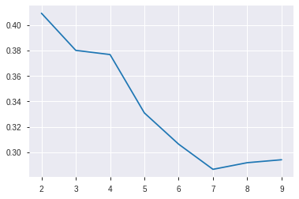

```python
# Silhoiette score analysis
from sklearn.metrics import silhouette_score
ss = []
for k in range(2, 10):
    kmeans = KMeans(n_clusters=k).fit(dataset3_1)
    ss.append([k, silhouette_score(dataset3_1, kmeans.labels_)])
plt.plot(pd.DataFrame(ss)[0], pd.DataFrame(ss)[1])
plt.savefig("silhouette.png")
```

### Question: Look at the Elbow Curve plot and choose the optimal number of cluster

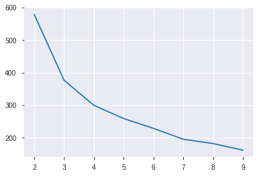

```python
# Elbow curve analysis for choosing the number of clusters
ss = []
for k in range(2, 10):
    kmeans = KMeans(n_clusters=k).fit(dataset3_1)
    ss.append([k, kmeans.inertia_])
plt.plot(pd.DataFrame(ss)[0], pd.DataFrame(ss)[1])
plt.savefig("elbow.png")
```

### Analysis

We observe that based on the graph obtained the optimal number of clusters are 3

## KMeans with the K we choose

```python
model_kmean = KMeans(n_clusters=3, random_state=42)
# After choosing the number of clusters building the model

model_kmean.fit(dataset3_1)
# Fitting the data into the model

data_km = pd.concat([pca_df2.reset_index().drop('index', axis=1), pd.Series(model_kmean.labels_).reset_index().drop('index', axis=1)], axis=1)
# Assigning the cluster id for each record based on the model

data_km.columns = ['country', 'PC1', 'PC2', 'PC3', 'PC4', 'ClusterID']

data_km.head()
# Printing out the top 5 records
```

|  | country | PC1 | PC2 | PC3 | PC4 | ClusterID |
| --- | --- | --- | --- | --- | --- | --- |
| 0 | Afghanistan | -3.064069 | 1.067549 | -0.355485 | 0.157476 | 0 |
| 1 | Albania | 0.725146 | -1.590426 | 0.096826 | -0.219602 | 1 |
| 2 | Algeria | 0.283845 | -0.402017 | 1.738614 | -0.275765 | 1 |
| 3 | Angola | -2.417680 | 2.681081 | 1.335811 | 0.131227 | 0 |
| 4 | Antigua and Barbuda | 3.727746 | 0.207475 | -0.952760 | 0.076251 | 2 |

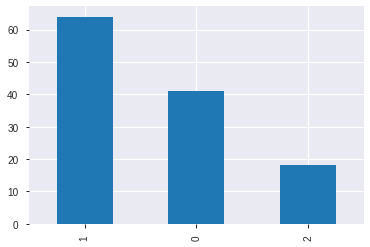

```python
# Check the count of observation per cluster
data_km['ClusterID'].value_counts().plot(kind='bar')
plt.savefig("cluster_formed.png")
```

#### Perform visualisations on the clusters that have been formed. You can do this by choosing the first two Principal Components (on the X-Y axes) and plotting a scatter plot of all the countries and differentiating the clusters.

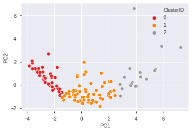

```python
# Plot the cluster with respect to cluesters obtained
sns.scatterplot(x='PC1', y='PC2', hue='ClusterID', data=data_km, palette='Set1')
plt.savefig("Clusters.png")
```

## Cluster Profiling

```python
datasetS = pd.merge(dataset, data_km[['country', 'ClusterID']], on='country')
datasetS.head()
```

|  | country | child_mort | exports | health | imports | income | inflation | life_expec | total_fer | gdpp | ClusterID |
| --- | --- | --- | --- | --- | --- | --- | --- | --- | --- | --- | --- |
| 0 | Afghanistan | 90.2 | 55.30 | 41.9174 | 248.297 | 1610 | 9.44 | 56.2 | 5.82 | 553 | 0 |
| 1 | Albania | 16.6 | 1145.20 | 267.8950 | 1987.740 | 9930 | 4.49 | 76.3 | 1.65 | 4090 | 1 |
| 2 | Algeria | 27.3 | 1712.64 | 185.9820 | 1400.440 | 12900 | 16.10 | 76.5 | 2.89 | 4460 | 1 |
| 3 | Angola | 119.0 | 2199.19 | 100.6050 | 1514.370 | 5900 | 22.40 | 60.1 | 6.16 | 3530 | 0 |
| 4 | Antigua and Barbuda | 10.3 | 5551.00 | 735.6600 | 7185.800 | 19100 | 1.44 | 76.8 | 2.13 | 12200 | 2 |

## Analysis of the Clusters

```python
datasetS.drop('country', axis=1).groupby("ClusterID").mean()
```

| ClusterID | child_mort | exports | health | imports | income | inflation | life_expec | total_fer | gdpp |
| --- | --- | --- | --- | --- | --- | --- | --- | --- | --- |
| 0 | 87.458537 | 305.972281 | 48.924817 | 387.687783 | 2235.195122 | 9.295732 | 60.687805 | 4.973902 | 926.317073 |
| 1 | 25.328125 | 1792.170875 | 314.926288 | 2008.418500 | 10057.968750 | 7.480172 | 71.520312 | 2.433125 | 4847.093750 |
| 2 | 15.550000 | 7894.067222 | 794.490611 | 7235.448889 | 23338.888889 | 5.098778 | 75.166667 | 2.105000 | 13117.222222 |

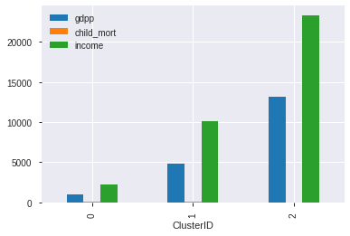

```python
datasetS[["gdpp", "child_mort", "income", "ClusterID"]].groupby("ClusterID").mean().plot(kind='bar')
```

### Analysis

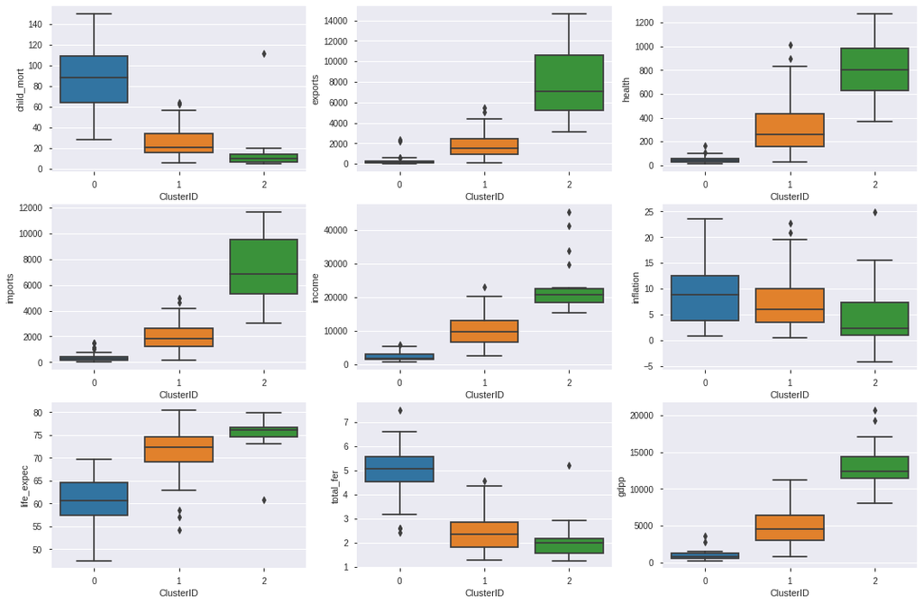

```python
var = list(datasetS.columns)
var.remove("country")
var.remove("ClusterID")
plt.figure(figsize=(18,12))
for i in enumerate(var):
    plt.subplot(3, 3, i[0]+1)
    sns.boxplot(x="ClusterID", y=i[1], data=datasetS)
plt.show()
plt.savefig("kmeans_groups.png")
```

```python
final_df = datasetS.loc[datasetS["ClusterID"] ==0, ['country', 'child_mort']]
final_df = final_df.sort_values(by="child_mort", ascending=False)
final_df.head(7)
```

|  | country | child_mort |
| --- | --- | --- |
| 26 | Chad | 150.0 |
| 25 | Central African Republic | 149.0 |
| 75 | Mali | 137.0 |
| 86 | Niger | 123.0 |
| 3 | Angola | 119.0 |
| 20 | Burkina Faso | 116.0 |
| 31 | Congo, Dem. Rep. | 116.0 |

### Cluster 0 is the desired result:

Extract the countries from Cluster-0 Reasons:

- Child mortality rate is high
- Exports and Imports of the countries in this cluster are very low as compared to the other cluster-countries.
- Gdpp is quite low low and even the health is very low.

**7 of the countries are:**

- Chad
- Central African Republic
- Mali
- Nigar
- Angola
- Burkina Faso
- Congo, Dem, Rep.

## Hierarchical Clustering

### Single Linkage

```python
dataset2 = scaler.fit_transform(dataset1)
SL_data = pd.DataFrame(dataset2)
SL_data.columns = ['child_mort', 'exports', 'health', 'imports', 'income', 'inflation', 'life_expec', 'total_fer', 'gdpp']
```

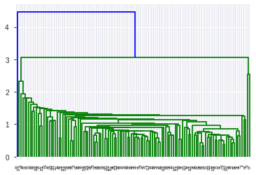

```python
merging_single = linkage(SL_data, method="single", metric="euclidean")
dendrogram(merging_single)
plt.show()
plt.savefig("sl.png")
```

```python
cluster_labels = cut_tree(merging_single, n_clusters=3).reshape(-1, )
cluster_labels.shape
```

```
(123,)
```

```python
# Assign Cluster Labels
SL_data["ClusterID"] = cluster_labels
SL_data.head()
```

|  | child_mort | exports | health | imports | income | inflation | life_expec | total_fer | gdpp | ClusterID |
| --- | --- | --- | --- | --- | --- | --- | --- | --- | --- | --- |
| 0 | 1.234389 | -0.727522 | -0.852750 | -0.792733 | -0.944913 | 0.275076 | -1.656258 | 1.688808 | -0.933016 | 0 |
| 1 | -0.758278 | -0.356029 | -0.095635 | -0.097999 | 0.065075 | -0.524405 | 1.062891 | -1.032374 | -0.146802 | 0 |
| 2 | -0.468583 | -0.162617 | -0.370076 | -0.332567 | 0.425612 | 1.350742 | 1.089947 | -0.223197 | -0.064558 | 0 |
| 3 | 2.014128 | 0.003224 | -0.656123 | -0.287063 | -0.424138 | 2.368263 | -1.128662 | 1.910679 | -0.271281 | 0 |
| 4 | -0.928846 | 1.145689 | 1.471565 | 1.978108 | 1.178248 | -1.017015 | 1.130531 | -0.719144 | 1.655910 | 0 |

```python
# Plots
sns.boxplot(x="ClusterID", y="gdpp", data=SL_data)
```

[output not shown]

### Cluster Profiling for Single Linkage

```python
# Plots
sns.boxplot(x="ClusterID", y="gdpp", data=SL_data)
```

[output not shown]

```python
SL_data.groupby("ClusterID").mean()
```

| ClusterID | child_mort | exports | health | imports | income | inflation | life_expec | total_fer | gdpp |
| --- | --- | --- | --- | --- | --- | --- | --- | --- | --- |
| 0 | 0.000569 | -0.099895 | -0.040209 | -0.072759 | -0.092985 | -0.033284 | -0.008648 | -0.003121 | -0.079371 |
| 1 | -0.932907 | 3.866458 | 1.625817 | 2.800133 | 4.103815 | 0.611020 | 1.029071 | -0.458119 | 3.389715 |
| 2 | 1.797534 | 4.254517 | 1.573484 | 3.130817 | 2.950583 | 2.772042 | -1.020437 | 1.290746 | 2.745095 |

### Analysis of the Clusters for Single Linkage

```python
SL_data["country"] = countries
var = list(SL_data.columns)
var.remove("country")
var.remove("ClusterID")
```

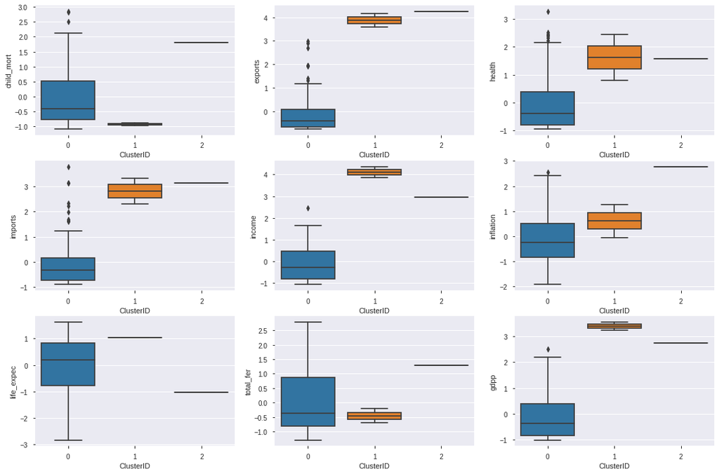

```python
plt.figure(figsize=(18,12))
for i in enumerate(var):
    plt.subplot(3, 3, i[0]+1)
    sns.boxplot(x="ClusterID", y=i[1], data=SL_data)
plt.show()
```

```python
SL_data["country"] = countries
final_df = SL_data.loc[SL_data["ClusterID"] ==0, ['country', 'child_mort']]
final_df = final_df.sort_values(by="child_mort", ascending=False)
final_df.head(7)
```

|  | country | child_mort |
| --- | --- | --- |
| 26 | Burundi | 2.853430 |
| 25 | Burkina Faso | 2.826356 |
| 75 | NaN | 2.501465 |
| 86 | Lebanon | 2.122425 |
| 3 | Angola | 2.014128 |
| 20 | Bosnia and Herzegovina | 1.932905 |
| 31 | Central African Republic | 1.932905 |

### Complete Linkage

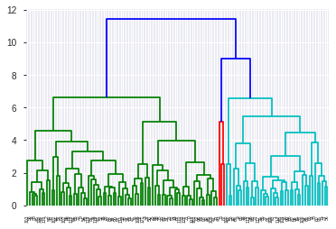

```python
dataset2 = scaler.fit_transform(dataset1)
CL_data = pd.DataFrame(dataset2)
CL_data.columns = ['child_mort', 'exports', 'health', 'imports', 'income', 'inflation', 'life_expec', 'total_fer', 'gdpp']
merging_complete = linkage(CL_data, method="complete", metric="euclidean")
dendrogram(merging_complete)
plt.show()
plt.savefig("cl.png")
```

```python
cluster_labels = cut_tree(merging_single, n_clusters=3).reshape(-1, )
cluster_labels.shape
```

```
(123,)
```

```python
# Assign Cluster Labels
CL_data["ClusterID"] = cluster_labels
CL_data.head()
```

|  | child_mort | exports | health | imports | income | inflation | life_expec | total_fer | gdpp | ClusterID |
| --- | --- | --- | --- | --- | --- | --- | --- | --- | --- | --- |
| 0 | 1.234389 | -0.727522 | -0.852750 | -0.792733 | -0.944913 | 0.275076 | -1.656258 | 1.688808 | -0.933016 | 0 |
| 1 | -0.758278 | -0.356029 | -0.095635 | -0.097999 | 0.065075 | -0.524405 | 1.062891 | -1.032374 | -0.146802 | 0 |
| 2 | -0.468583 | -0.162617 | -0.370076 | -0.332567 | 0.425612 | 1.350742 | 1.089947 | -0.223197 | -0.064558 | 0 |
| 3 | 2.014128 | 0.003224 | -0.656123 | -0.287063 | -0.424138 | 2.368263 | -1.128662 | 1.910679 | -0.271281 | 0 |
| 4 | -0.928846 | 1.145689 | 1.471565 | 1.978108 | 1.178248 | -1.017015 | 1.130531 | -0.719144 | 1.655910 | 0 |

### Cluster Profiling for Complete Linkage

```python
# Plots
sns.boxplot(x="ClusterID", y="gdpp", data=CL_data)
```

[output not shown]

```python
CL_data.groupby("ClusterID").mean()
```

| ClusterID | child_mort | exports | health | imports | income | inflation | life_expec | total_fer | gdpp |
| --- | --- | --- | --- | --- | --- | --- | --- | --- | --- |
| 0 | 0.000569 | -0.099895 | -0.040209 | -0.072759 | -0.092985 | -0.033284 | -0.008648 | -0.003121 | -0.079371 |
| 1 | -0.932907 | 3.866458 | 1.625817 | 2.800133 | 4.103815 | 0.611020 | 1.029071 | -0.458119 | 3.389715 |
| 2 | 1.797534 | 4.254517 | 1.573484 | 3.130817 | 2.950583 | 2.772042 | -1.020437 | 1.290746 | 2.745095 |

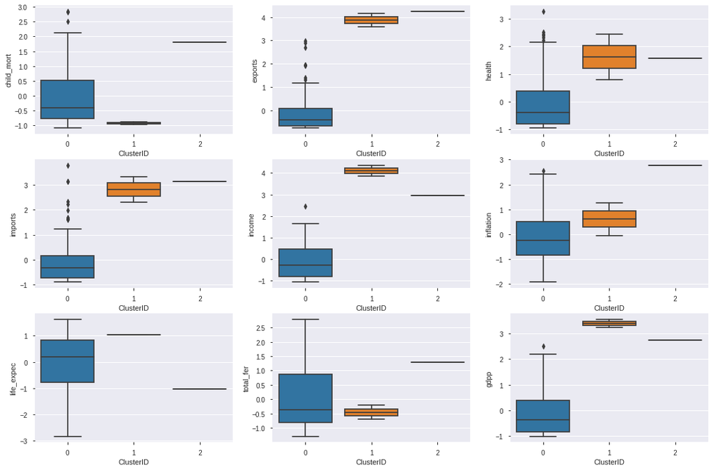

```python
var = list(CL_data.columns)
var.remove("ClusterID")
plt.figure(figsize=(18,12))
for i in enumerate(var):
    plt.subplot(3, 3, i[0]+1)
    sns.boxplot(x="ClusterID", y=i[1], data=CL_data)
plt.show()
plt.savefig("cl_groups.png")
```

```python
CL_data["country"] = countries
final_df = CL_data.loc[CL_data["ClusterID"] ==0, ['country', 'child_mort']]
final_df = final_df.sort_values(by="child_mort", ascending=False)
final_df.head(7)
```

|  | country | child_mort |
| --- | --- | --- |
| 26 | Burundi | 2.853430 |
| 25 | Burkina Faso | 2.826356 |
| 75 | NaN | 2.501465 |
| 86 | Lebanon | 2.122425 |
| 3 | Angola | 2.014128 |
| 20 | Bosnia and Herzegovina | 1.932905 |
| 31 | Central African Republic | 1.932905 |